# I will start with a pretrained word embedding on this IMDB reviews use case

# There is a decent increase again from 64.19% to 66.24% with increase in training samples from 5000 to 7500

Lets increase the training samples to 10000

```
Found 88582 unique tokens.
Shape of data tensor: (25000, 150)
Shape of label tensor: (25000,)
Model: "sequential_43"
_________________________________________________________________
 Layer (type)                Output Shape              Param #
=================================================================
 embedding_43 (Embedding)    (None, 150, 100)          1000000

 flatten_35 (Flatten)        (None, 15000)             0

 dense_78 (Dense)            (None, 32)                480032

 dense_79 (Dense)            (None, 1)                 33

=================================================================
Total params: 1480065 (5.65 MB)
Trainable params: 1480065 (5.65 MB)
Non-trainable params: 0 (0.00 Byte)
_________________________________________________________________
```

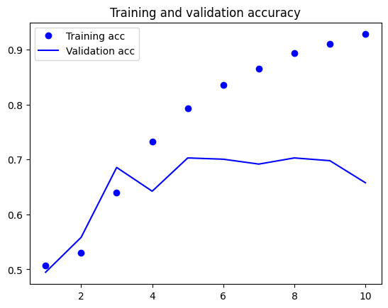

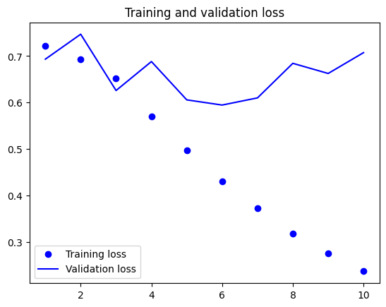

```
Training Accuracy = 0.9280999898910522
Validation Accuracy = 0.6577000021934509
```

```python
maxlen = 150 # Cut off reviews after 150 words
training_samples = 10000 # Number of training samples
validation_samples = 10000 # Number of validation samples
max_words = 10000 # Consider only the top 10000 words

x_train, y_train, x_val, y_val, word_index = preprocess_text_data(texts, labels, max_words, maxlen, training_samples, validation_samples)


model = Sequential()
model.add(Embedding(max_words, embedding_dim, input_length=maxlen))
model.add(Flatten())
model.add(Dense(32, activation='relu'))
model.add(Dense(1, activation='sigmoid'))
model.summary()
model.layers[0].set_weights([embedding_matrix])
model.layers[0].trainable = False

model.compile(optimizer='rmsprop',loss='binary_crossentropy',metrics=['acc'])
history = model.fit(x_train, y_train, epochs=10, batch_size=32, validation_data=(x_val, y_val))
model.save_weights('pre_trained_glove_model_10000_20.h5')


acc = history.history['acc']
val_acc = history.history['val_acc']
loss = history.history['loss']
val_loss = history.history['val_loss']
epochs = range(1, len(acc) + 1)
plt.plot(epochs, acc, 'bo', label='Training acc')
plt.plot(epochs, val_acc, 'b', label='Validation acc')
plt.title('Training and validation accuracy')
plt.legend()
plt.figure()
plt.plot(epochs, loss, 'bo', label='Training loss')
plt.plot(epochs, val_loss, 'b', label='Validation loss')
plt.title('Training and validation loss')
plt.legend()
plt.show()

# Access the training and validation accuracy from the history by taking the last epoch's accuracy
training_accuracy = history.history['acc']
print(f"Training Accuracy = {training_accuracy[-1]}")

validation_accuracy = history.history['val_acc']
print(f"Validation Accuracy = {validation_accuracy[-1]}")
```

There is a decrease in validaiton accuracy(66.24% to 65.77%). Lets increase it to 15000 training samples

```
Found 88582 unique tokens.
Shape of data tensor: (25000, 150)
Shape of label tensor: (25000,)
Model: "sequential_63"
_________________________________________________________________
 Layer (type)                Output Shape              Param #
=================================================================
 embedding_63 (Embedding)    (None, 150, 100)          1000000

 flatten_37 (Flatten)        (None, 15000)             0

 dense_100 (Dense)           (None, 32)                480032

 dense_101 (Dense)           (None, 1)                 33

=================================================================
Total params: 1480065 (5.65 MB)
Trainable params: 1480065 (5.65 MB)
Non-trainable params: 0 (0.00 Byte)
_________________________________________________________________
```

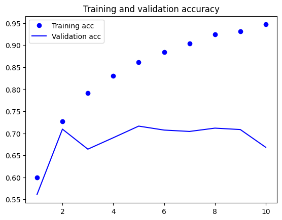

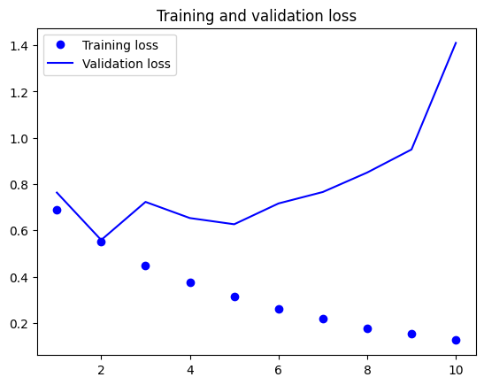

```
Training Accuracy = 0.9468666911125183
Validation Accuracy = 0.6682000160217285
```

```python
maxlen = 150 # Cut off reviews after 150 words
training_samples = 15000 # Number of training samples
validation_samples = 10000 # Number of validation samples
max_words = 10000 # Consider only the top 10000 words

x_train, y_train, x_val, y_val, word_index = preprocess_text_data(texts, labels, max_words, maxlen, training_samples, validation_samples)


model = Sequential()
model.add(Embedding(max_words, embedding_dim, input_length=maxlen))
model.add(Flatten())
model.add(Dense(32, activation='relu'))
model.add(Dense(1, activation='sigmoid'))
model.summary()
model.layers[0].set_weights([embedding_matrix])
model.layers[0].trainable = False

model.compile(optimizer='rmsprop',loss='binary_crossentropy',metrics=['acc'])
history = model.fit(x_train, y_train, epochs=10, batch_size=32, validation_data=(x_val, y_val))
model.save_weights('pre_trained_glove_model_15000_21.h5')


acc = history.history['acc']
val_acc = history.history['val_acc']
loss = history.history['loss']
val_loss = history.history['val_loss']
epochs = range(1, len(acc) + 1)
plt.plot(epochs, acc, 'bo', label='Training acc')
plt.plot(epochs, val_acc, 'b', label='Validation acc')
plt.title('Training and validation accuracy')
plt.legend()
plt.figure()
plt.plot(epochs, loss, 'bo', label='Training loss')
plt.plot(epochs, val_loss, 'b', label='Validation loss')
plt.title('Training and validation loss')
plt.legend()
plt.show()

# Access the training and validation accuracy from the history by taking the last epoch's accuracy
training_accuracy = history.history['acc']
print(f"Training Accuracy = {training_accuracy[-1]}")

validation_accuracy = history.history['val_acc']
print(f"Validation Accuracy = {validation_accuracy[-1]}")
```

# Again the validaiton accuracy is slightly higher than previous model

# Nevertheless, models that did not utilize pre-trained word embeddings exhibited superior validation accuracy. However, their training accuracy approached 1, indicating perfect learning of the training data and a higher susceptibility to overfitting compared to models using pre-trained embeddings, where features are already learned independently of the training data.

# If there is a lot of data, training our own embedding works better than using pre-trained embeddings on that data.

# Using the model with Simple RNN or LSTM

```
Found 88582 unique tokens.
Shape of data tensor: (25000, 150)
Shape of label tensor: (25000,)
```

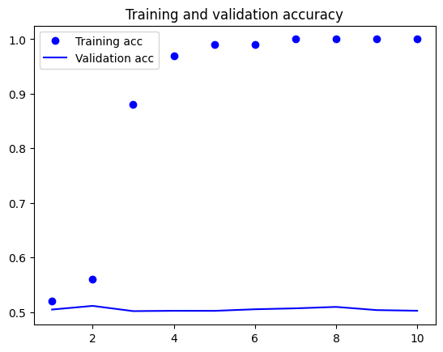

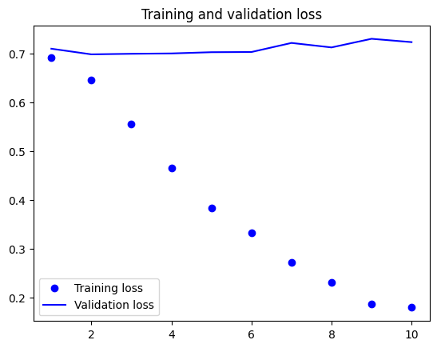

```
Training Accuracy = 1.0
Validation Accuracy = 0.5023000240325928
```

```python
maxlen = 150 # Cut off reviews after 150 words
training_samples = 100 # Number of training samples
validation_samples = 10000 # Number of validation samples
max_words = 10000 # Consider only the top 10000 words

x_train, y_train, x_val, y_val, word_index = preprocess_text_data(texts, labels, max_words, maxlen, training_samples, validation_samples)

model = Sequential()
model.add(Embedding(max_words, 32))
model.add(SimpleRNN(32))
model.add(Dense(1, activation='sigmoid'))
model.compile(optimizer='rmsprop', loss='binary_crossentropy', metrics=['acc'])
history = model.fit(x_train, y_train, epochs=10, batch_size=32, validation_data=(x_val, y_val))

model.save_weights('simple_RNN_model_100_22.h5')


acc = history.history['acc']
val_acc = history.history['val_acc']
loss = history.history['loss']
val_loss = history.history['val_loss']
epochs = range(1, len(acc) + 1)
plt.plot(epochs, acc, 'bo', label='Training acc')
plt.plot(epochs, val_acc, 'b', label='Validation acc')
plt.title('Training and validation accuracy')
plt.legend()
plt.figure()
plt.plot(epochs, loss, 'bo', label='Training loss')
plt.plot(epochs, val_loss, 'b', label='Validation loss')
plt.title('Training and validation loss')
plt.legend()
plt.show()

# Access the training and validation accuracy from the history by taking the last epoch's accuracy
training_accuracy = history.history['acc']
print(f"Training Accuracy = {training_accuracy[-1]}")

validation_accuracy = history.history['val_acc']
print(f"Validation Accuracy = {validation_accuracy[-1]}")
```

# The validation accuracy(50.2%) is lower than the model with pre-trained embeddings vs training our own embeddings model we already built above at the beginning.

Lets increase the training samples to 1000

```
Found 88582 unique tokens.
Shape of data tensor: (25000, 150)
Shape of label tensor: (25000,)
```

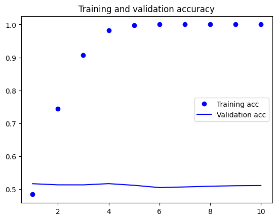

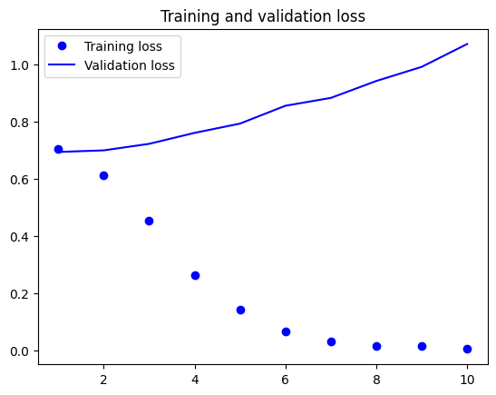

```
Training Accuracy = 1.0
Validation Accuracy = 0.5109999775886536
```

```python
maxlen = 150 # Cut off reviews after 150 words
training_samples = 1000 # Number of training samples
validation_samples = 10000 # Number of validation samples
max_words = 10000 # Consider only the top 10000 words

x_train, y_train, x_val, y_val, word_index = preprocess_text_data(texts, labels, max_words, maxlen, training_samples, validation_samples)

model = Sequential()
model.add(Embedding(max_words, 32))
model.add(SimpleRNN(32))
model.add(Dense(1, activation='sigmoid'))
model.compile(optimizer='rmsprop', loss='binary_crossentropy', metrics=['acc'])
history = model.fit(x_train, y_train, epochs=10, batch_size=32, validation_data=(x_val, y_val))

model.save_weights('simple_RNN_model_1000.h5')


acc = history.history['acc']
val_acc = history.history['val_acc']
loss = history.history['loss']
val_loss = history.history['val_loss']
epochs = range(1, len(acc) + 1)
plt.plot(epochs, acc, 'bo', label='Training acc')
plt.plot(epochs, val_acc, 'b', label='Validation acc')
plt.title('Training and validation accuracy')
plt.legend()
plt.figure()
plt.plot(epochs, loss, 'bo', label='Training loss')
plt.plot(epochs, val_loss, 'b', label='Validation loss')
plt.title('Training and validation loss')
plt.legend()
plt.show()

# Access the training and validation accuracy from the history by taking the last epoch's accuracy
training_accuracy = history.history['acc']
print(f"Training Accuracy = {training_accuracy[-1]}")

validation_accuracy = history.history['val_acc']
print(f"Validation Accuracy = {validation_accuracy[-1]}")
```

# The validation accuracy has increased from 50.2% to 51.1% using 1000 training examples

Lets increase the training samples to 2000

```
Found 88582 unique tokens.
Shape of data tensor: (25000, 150)
Shape of label tensor: (25000,)
```

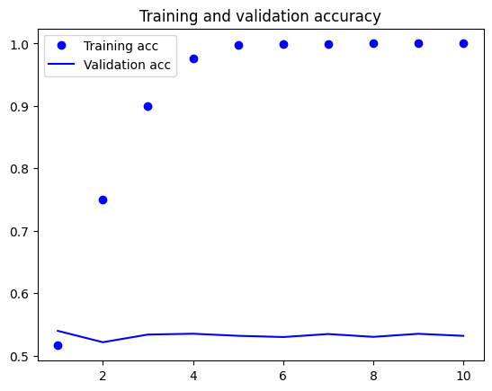

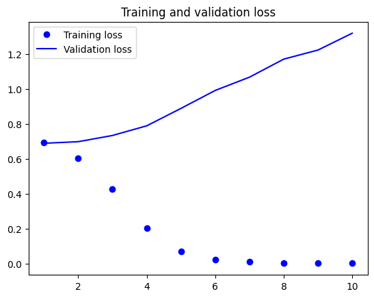

```
Training Accuracy = 1.0
Validation Accuracy = 0.5315999984741211
```

```python
maxlen = 150 # Cut off reviews after 150 words
training_samples = 2000 # Number of training samples
validation_samples = 10000 # Number of validation samples
max_words = 10000 # Consider only the top 10000 words

x_train, y_train, x_val, y_val, word_index = preprocess_text_data(texts, labels, max_words, maxlen, training_samples, validation_samples)

model = Sequential()
model.add(Embedding(max_words, 32))
model.add(SimpleRNN(32))
model.add(Dense(1, activation='sigmoid'))
model.compile(optimizer='rmsprop', loss='binary_crossentropy', metrics=['acc'])
history = model.fit(x_train, y_train, epochs=10, batch_size=32, validation_data=(x_val, y_val))

model.save_weights('simple_RNN_model_2000.h5')


acc = history.history['acc']
val_acc = history.history['val_acc']
loss = history.history['loss']
val_loss = history.history['val_loss']
epochs = range(1, len(acc) + 1)
plt.plot(epochs, acc, 'bo', label='Training acc')
plt.plot(epochs, val_acc, 'b', label='Validation acc')
plt.title('Training and validation accuracy')
plt.legend()
plt.figure()
plt.plot(epochs, loss, 'bo', label='Training loss')
plt.plot(epochs, val_loss, 'b', label='Validation loss')
plt.title('Training and validation loss')
plt.legend()
plt.show()

# Access the training and validation accuracy from the history by taking the last epoch's accuracy
training_accuracy = history.history['acc']
print(f"Training Accuracy = {training_accuracy[-1]}")

validation_accuracy = history.history['val_acc']
print(f"Validation Accuracy = {validation_accuracy[-1]}")
```